# Homework week 10 - day 1

```r
library(tidyverse)
library(janitor)
library(modelr)
library(broom)
library(ggfortify)
```

# 1. Load the data into a dataframe project

```r
project <- read_csv("data/project_management.csv") %>%
clean_names()
```

```r
glimpse(project)
```

```
Rows: 50
Columns: 3
$ x1               <dbl> 1, 2, 3, 4, 5, 6, 7, 8, 9, 10, 11, 12, 13, 14, 15, 16, 17, 18, 19, 20, 21, 22, 23, 24, 25, 26, 27, 28, 29, 30, 31, …
$ estimated_length <dbl> 12, 16, 16, 18, 22, 19, 18, 18, 18, 15, 15, 16, 12, 14, 11, 13, 17, 15, 11, 18, 17, 13, 15, 10, 17, 13, 16, 13, 11,…
$ actual_length    <dbl> 17, 22, 23, 25, 39, 24, 24, 21, 23, 20, 19, 22, 14, 18, 17, 19, 20, 13, 16, 21, 19, 15, 16, 12, 20, 20, 24, 21, 16,…
```

## 2. Plot the data, taking estimated_length as the independent variable and actual_length as the dependent variable.

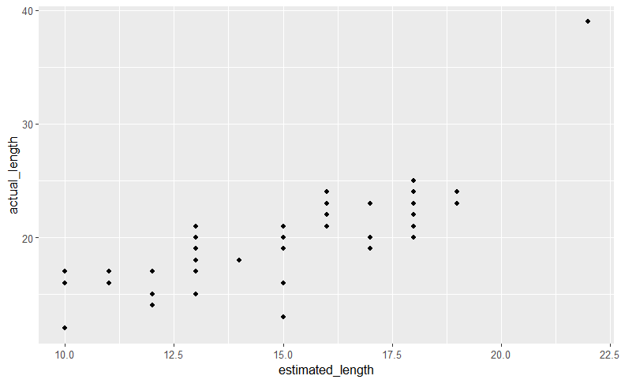

```r
project %>%
  ggplot()+
  aes(x = estimated_length, y = actual_length)+
  geom_point()
```

## 3. Calculate the correlation coefficient of estimated_length and actual_length and interpret the value you obtain.

```r
project %>%
  summarise(correlation = cor(estimated_length, actual_length))
```

| correlation |
| --- |
| 0.8046597 |

The two variables seems to be very strongly positively correlated!

## 4. Perform a simple linear regression using actual_length as the dependent variable, and estimated_length as the independent variable. Save the model object to a variable.

```r
model <- lm(formula = actual_length ~ estimated_length, data = project)
model
```

```
Call:
lm(formula = actual_length ~ estimated_length, data = project)

Coefficients:
     (Intercept)  estimated_length
           1.416             1.223
```

```r
summary(model)
```

```
Call:
lm(formula = actual_length ~ estimated_length, data = project)

Residuals:
    Min      1Q  Median      3Q     Max
-6.7687 -1.6513  0.1195  1.1252 10.6669

Coefficients:
                 Estimate Std. Error t value Pr(>|t|)
(Intercept)        1.4164     2.0069   0.706    0.484
estimated_length   1.2235     0.1303   9.389 1.91e-12 ***
---
Signif. codes:  0 ‘***’ 0.001 ‘**’ 0.01 ‘*’ 0.05 ‘.’ 0.1 ‘ ’ 1

Residual standard error: 2.606 on 48 degrees of freedom
Multiple R-squared:  0.6475,    Adjusted R-squared:  0.6401
F-statistic: 88.16 on 1 and 48 DF,  p-value: 1.911e-12
```

```r
project <- project %>%
  select(-x1) %>%
  add_predictions(model) %>%
  add_residuals(model)

project
```

| estimated_length | actual_length | pred | resid |
| --- | --- | --- | --- |
| 12 | 17 | 16.09825 | 0.90175491 |
| 16 | 22 | 20.99220 | 1.00779961 |
| 16 | 23 | 20.99220 | 2.00779961 |
| 18 | 25 | 23.43918 | 1.56082196 |
| 22 | 39 | 28.33313 | 10.66686666 |
| 19 | 24 | 24.66267 | -0.66266687 |
| 18 | 24 | 23.43918 | 0.56082196 |
| 18 | 21 | 23.43918 | -2.43917804 |
| 18 | 23 | 23.43918 | -0.43917804 |
| 15 | 20 | 19.76871 | 0.23128844 |

[output cut: 40 more lines]

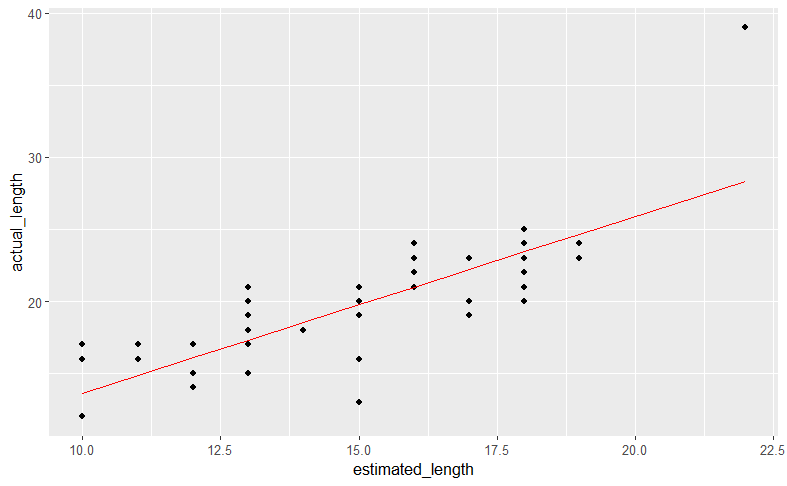

```r
project %>%
  ggplot(aes(x = estimated_length))+
  geom_point(aes(y = actual_length))+
  geom_line(aes(y = pred), colour = "red")
```

```r
NA
```

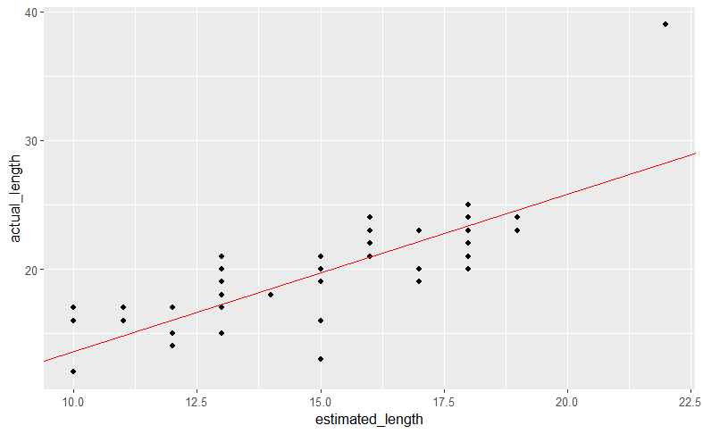

```r
project %>%
  ggplot(aes(x = estimated_length, y = actual_length)) +
  geom_point() +
  geom_abline(
    intercept = model$coefficients[1],
    slope = model$coefficients[2],
    col = "red"
  )
```

## 5. Interpret the regression coefficient of estimated_length (i.e. slope, gradient) you obtain from the model. How do you interpret the r2 value reported by the model?

```r
glance_output <- clean_names(glance(model))
glance_output
```

| r_squared | adj_r_squared | sigma | statistic | p_value | df | log_lik | aic | bic | deviance | df_residual | nobs |
| --- | --- | --- | --- | --- | --- | --- | --- | --- | --- | --- | --- |
| 0.6474772 | 0.640133 | 2.606163 | 88.16142 | 1.911284e-12 | 1 | -117.8203 | 241.6407 | 247.3767 | 326.0201 | 48 | 50 |

```r
model$coefficients[1]
```

```
(Intercept)
   1.416379
```

```r
model$coefficients[2]
```

```
estimated_length
        1.223489
```

```r
glance_output$r_squared
```

```
[1] 0.6474772
```

This says that the 64,7% of the variation of actual_length is explained by variation in extimated_length.

## 6. Is the relationship statistically significant? Remember, to assess this you need to check the p-value of the regression coefficient (or slope/gradient). But you should first check the regression diagnostic plots to see if a linear regression model is appropriate and therefore if the p-value will be reliable (don’t worry about any outlier points you see in the diagnostic plots, we’ll return to them in the extension).

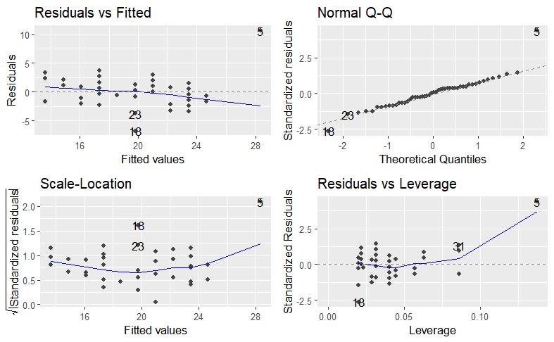

```r
autoplot(model)
```

1. That relationship is actually linear.
2. The residuals should be normally distributed!!!
3. Homosscedastic errors
   - Constant variance

[figure not shown]

```r
tidy_output <- clean_names(tidy(model))
tidy_output
```

| term | estimate | std_error | statistic | p_value |
| --- | --- | --- | --- | --- |
| (Intercept) | 1.416379 | 2.0069491 | 0.7057375 | 4.837627e-01 |
| estimated_length | 1.223489 | 0.1303049 | 9.3894314 | 1.911284e-12 |

The relationship is statistically significant, as the p -value of the slope is much less than a typical α of 0.05.

[figure not shown]

[figure not shown]

[figure not shown]

```r
project <- add_case(project, actual_length = 3000, estimated_length = 100)

model_1 <- lm(formula = actual_length ~ estimated_length, data = project)

plot(model_1, which = c(2, 3, 5))
```

```r
NA
NA
```